# CEMA 0907: Problem Set 4

Ben Levy

```r
library(tidyverse)
library(moderndive)
library(ISLR) # Install this!
library(nycflights13)
```

## Exercise 1

The following exercises use the `Credit` dataset from the `ISLR` package.

```r
View(Credit)
?Credit
```

### (a)

Construct a scatterplot of `Balance` (y) against `Income` (x), and overlay a line of best fit. Describe this relationship. Would a linear model be appropriate for examining the relationship between these variables?

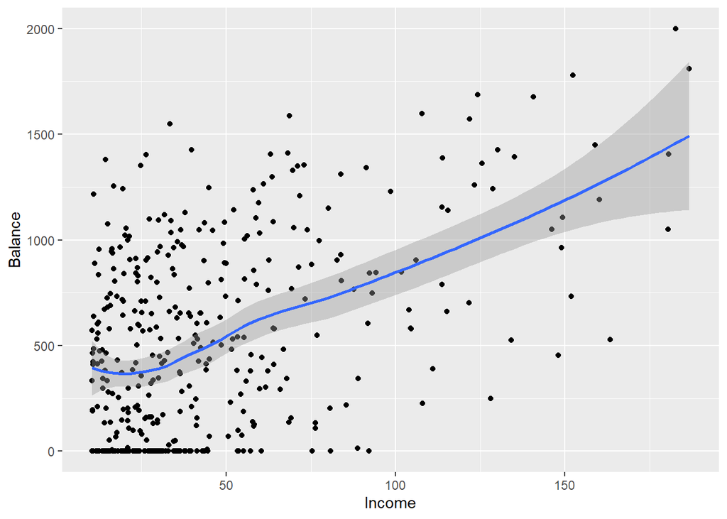

```r
Credit %>%
  ggplot(aes(x = Income, y = Balance)) +
  geom_point() +
  geom_smooth()
```

Despite the relatively wide confidence interval shown in the line of best fit, a somewhat linear line is formed by `geom_smooth`. Thus, I would say a linear regression could be a good fit in this scenario. The relationship is positive.

### (b)

Regardless of your answer to (a), fit a regression model for this relationship using `lm()`. Call this model `balance_fit`. Interpret the slope coefficient.

```r
balance_fit <- lm(Balance ~ Income, data = Credit)

get_regression_table(balance_fit)
```

```
## # A tibble: 2 × 7
##   term      estimate std_error statistic p_value lower_ci upper_ci
##   <chr>        <dbl>     <dbl>     <dbl>   <dbl>    <dbl>    <dbl>
## 1 intercept   247.      33.2        7.42       0   181.     312.
## 2 Income        6.05     0.579     10.4        0     4.91     7.19
```

For every increase (one unit) in income, income increases by 6.048 units. Thus, a positive correlation can be observed from these data.

## Exercise 2

This exercise will look at data on Antarctican penguins, because who doesn’t love penguins? The data come from the Palmer Station in Antarctica, and are hosted in a [TidyTuesday repository](https://github.com/rfordatascience/tidytuesday/blob/master/data/2020/2020-07-28/readme.md)

Load the data below:

```r
penguins = read.csv('https://raw.githubusercontent.com/rfordatascience/tidytuesday/master/data/2020/2020-07-28/penguins.csv')
```

```r
View(penguins)
```

### (a)

Create a scatterplot to display the relationship between penguin *bill length* (x) and *bill depth* (y). Describe the association between these two variables.

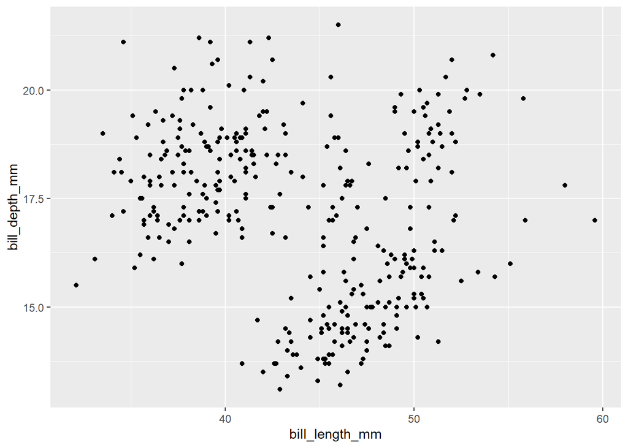

```r
penguins %>%
  ggplot(aes(x = bill_length_mm, y = bill_depth_mm)) +
  geom_point()
```

There seems to be a *very* loose negative correlation.

### (b)

Add the `color = ~species` option to your scatterplot in (a) to create a colored scatterplot with the `species` variable added. Describe any trends that you observe here that you didn’t see in the previous plot

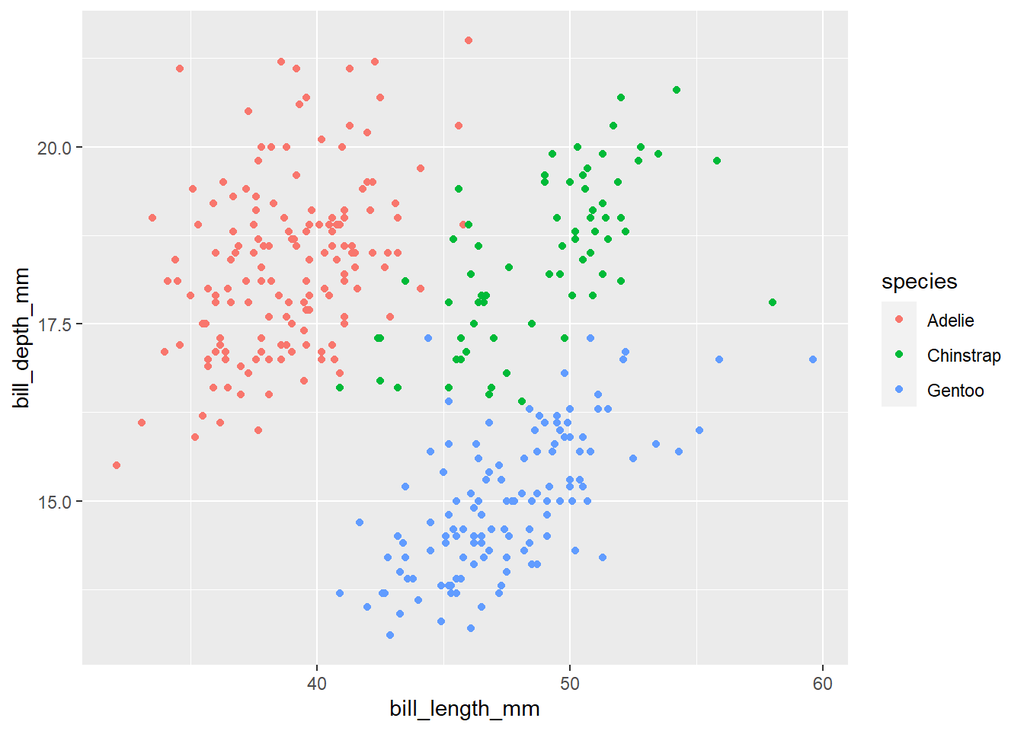

```r
penguins %>%
  ggplot(aes(x = bill_length_mm, y = bill_depth_mm)) +
  geom_point(aes(color = species))
```

Within the Adelie species, we can observe a loose positive correlation/trend. On the other hand, we can see a somewhat stronger positive correlation in Chinstraps. Finally, we can observe a potentially stronger positive correlation in Gentoos. Though, these observations are the opposite of what we see in the macro level, where a loose negative trend can be observed.

### (c)

Fit a regression model to describe a penguin’s *bill depth* as a function of *bill length*. Interpret the coefficient associated with `bill_length_mm`.

```r
bill_length_fit <- lm(bill_depth_mm ~ bill_length_mm, data = penguins)

get_regression_table(bill_length_fit)
```

```
## # A tibble: 2 × 7
##   term           estimate std_error statistic p_value lower_ci upper_ci
##   <chr>             <dbl>     <dbl>     <dbl>   <dbl>    <dbl>    <dbl>
## 1 intercept        20.9       0.844     24.7        0   19.2     22.5
## 2 bill_length_mm   -0.085     0.019     -4.46       0   -0.123   -0.048
```

### (d)

Does this association match what you might expect from the scatterplot in (b)? Explain.

While this association does not match what I expected at the micro level from (b), it does at the macro level. In other words, looking at the overall data, I expected a slight negative association; however, I would’ve expected positive associations if looking at each species individually.

## Exercise 3

**This exercise is OPTIONAL! Try it if you want extra practice.**

Use the `nycflights13` package and the `flights` and `planes` tables to answer the following questions.

```r
View(flights)
View(planes)
```

### (a)

What are the three oldest planes that flew from New York City airports in 2013? Report a table with the `tailnum`, `year` manufactured, `manufacturer`, and `age` (in 2013) of the three oldest planes.

*Some Hints*:

- You’ll need to use an appropriate `_join()` to join the `flights` and `planes` tables together. Call this table `flights_planes`.
- Using `flights_planes`:
  - The `age` column isn’t initially present, but you can create it using existing columns.
  - Because the same planes might have been used for many flights in 2013, use `distinct(tailnum, .keep_all = TRUE)` in your pipeline to retain distinct rows based on `tailnum`, but keep all other columns associated with that row.

```r
flights_planes <- left_join(flights, planes, by = c("tailnum"))
flights_planes %>%
  mutate(age = 2013-year.y) %>%
  distinct(tailnum, .keep_all = TRUE) %>%
  slice_max(age, n = 3) %>%
  select(tailnum, year.y, manufacturer, age)
```

```
## # A tibble: 3 × 4
##   tailnum year.y manufacturer   age
##   <chr>    <int> <chr>        <dbl>
## 1 N381AA    1956 DOUGLAS         57
## 2 N201AA    1959 CESSNA          54
## 3 N567AA    1959 DEHAVILLAND     54
```

### (b)

Which manufacturer was used the most frequently for flights from New York City in 2013? Report a table with the name of the manufacturer, along with the number of flights using planes made by that manufacturer.

```r
flights_planes %>%
  count(manufacturer) %>%
  slice_max(n, n = 1)
```

```
## # A tibble: 1 × 2
##   manufacturer     n
##   <chr>        <int>
## 1 BOEING       82912
```

## All done!

Knit the completed R Markdown file as a HTML document (click the “Knit” button at the top of the editor window) and upload it to Canvas.